## Subject :- M507 Methods of Prediction Individual Project

## Name :- Harjot Singh

## Student ID :- GH1048197

# Flight Price Predication using Artifical Neural Network

## 1. Introduction

One of the most dynamic sectors where ticket prices fluctuate often is the airline sector; this is because there are many things that affect ticket prices, e.g., demand for travel, airline competition, seasonal change, flight duration, route popularity and stopover numbers. The volatility of this makes it challenging to for passengers to know when they should buy reasonable priced tickets. Precise pricing predictions can be valuable for customers and airline companies alike, enabling them to make informed decisions and optimize their pricing strategies.

In the last few years, machine learning and deep learning methods have gained popularity in different industries to address prediction problems. One of these methods is the Artificial Neural Networks (ANNs), which has been proved to be good at finding complex and non-linear relationships in large-scale data. Patterns found from past flight data can be used to create reliable estimates of future ticket prices with the help of ANNs. The aim of the project is to create this ANN-based flight price prediction model using historical airline information data set and test and validate the model's accuracy of predicting ticket price.

## 2. Problem Statement

The cost of a flight ticket depends on various factors such as the airline on which the ticket is bought, the source of departure, the destination point, the flight time and the number of stops. However, it's difficult to predict ticket prices using traditional means owing to the interaction among these variables. The timing of flights is often an unknown to customers, and it is crucial for airlines and travel agencies to have a good understanding of their ticket prices to better manage their profits and customer satisfaction.

The key issue being resolved in this study is to develop a predictive model that can be used to estimate the ticket price for an air flight when given the past air flight data. The overall goal of the project is to apply Artificial Neural Networks (ANN) to analyse the flight attributes and make predictions about the price of flights. This model can help customers make informed decisions about their bookings and help businesses optimize their pricing strategies.

## 3. Dataset Overview

Dataset link - https://www.kaggle.com/datasets/jillanisofttech/flight-price-prediction-dataset

This project's dataset is the Flight Price Prediction dataset from Kaggle. It includes 10,683 flights and 11 attributes that are associated with an airline trip - airline name, source, destination, trip date, departure time, arrival time, duration, number of stops, and other flight information. The answer variable is ticket price—in this case, a flight ticket's cost. This dataset consists of categorical variables and numerical variables, which can be used for machine learning and deep learning applications. Knowing the structure and properties of the dataset is crucial for successful preprocessing, feature engineering and creating an accurate flight price prediction model.

## Step 1- Import Required Libraries

```python
# Import Libraries
import pandas as pd
import numpy as np

import matplotlib.pyplot as plt
import seaborn as sns

from sklearn.model_selection import train_test_split
from sklearn.preprocessing import StandardScaler
from sklearn.metrics import mean_absolute_error, mean_squared_error, r2_score

import tensorflow as tf

from tensorflow.keras.models import Sequential
from tensorflow.keras.layers import Dense, Dropout
from tensorflow.keras.callbacks import EarlyStopping
```

This cell loads all the necessary libraries to work with this flight price prediction project. Pandas and NumPy are used for data manipulation and numerical operations. For visualization purposes to get to point of exploratory data analysis, matplotlib and seaborn are imported. The libraries used in scikit-learn are covered for data preprocessing, splitting the data into training and testing subset, data scaling and model evaluation. The TensorFlow and the Keras libraries are imported to build, train and evaluate deep learning models. By importing all relevant libraries at the outset, the notebook becomes available to all tools that process or analyze data, machine learning and visualization tools throughout the project.

## Step 2 - Load the Dataset

```python
# Load Dataset
df = pd.read_excel("/content/drive/MyDrive/Data_Train.xlsx")

df.head()
```

|  | Airline | Date_of_Journey | Source | Destination | Route | Dep_Time | Arrival_Time | Duration | Total_Stops | Additional_Info | Price |
| --- | --- | --- | --- | --- | --- | --- | --- | --- | --- | --- | --- |
| 0 | IndiGo | 24/03/2019 | Banglore | New Delhi | BLR → DEL | 22:20 | 01:10 22 Mar | 2h 50m | non-stop | No info | 3897 |
| 1 | Air India | 1/05/2019 | Kolkata | Banglore | CCU → IXR → BBI → BLR | 05:50 | 13:15 | 7h 25m | 2 stops | No info | 7662 |
| 2 | Jet Airways | 9/06/2019 | Delhi | Cochin | DEL → LKO → BOM → COK | 09:25 | 04:25 10 Jun | 19h | 2 stops | No info | 13882 |
| 3 | IndiGo | 12/05/2019 | Kolkata | Banglore | CCU → NAG → BLR | 18:05 | 23:30 | 5h 25m | 1 stop | No info | 6218 |
| 4 | IndiGo | 01/03/2019 | Banglore | New Delhi | BLR → NAG → DEL | 16:50 | 21:35 | 4h 45m | 1 stop | No info | 13302 |

This cell uses the read_excel() function to read the flight price data into a Pandas DataFrame. Once the data set has been loaded, the first few records are printed using the head() function. The first few rows serve as an effective way to check if the dataset has been loaded and gives an idea of the variables available. The data includes airline, origin city, destination city, departure time, arrival time, flight date, time spent in flight, number of stops and ticket price. Later on, these variables will be used to create a predictive model that can be used to estimate the flight cost.

## Step 3 - Initial Dataset Inspection

```python
print(df.shape)

df.info()

df.describe()
```

```
(10683, 11)
<class 'pandas.core.frame.DataFrame'>
RangeIndex: 10683 entries, 0 to 10682
Data columns (total 11 columns):
 #   Column           Non-Null Count  Dtype
---  ------           --------------  -----
 0   Airline          10683 non-null  object
 1   Date_of_Journey  10683 non-null  object
 2   Source           10683 non-null  object
 3   Destination      10683 non-null  object
 4   Route            10682 non-null  object
 5   Dep_Time         10683 non-null  object
 6   Arrival_Time     10683 non-null  object
 7   Duration         10683 non-null  object
 8   Total_Stops      10682 non-null  object
 9   Additional_Info  10683 non-null  object
 10  Price            10683 non-null  int64
dtypes: int64(1), object(10)
memory usage: 918.2+ KB
```

|  | Price |
| --- | --- |
| count | 10683.000000 |
| mean | 9087.064121 |
| std | 4611.359167 |
| min | 1759.000000 |
| 25% | 5277.000000 |
| 50% | 8372.000000 |
| 75% | 12373.000000 |
| max | 79512.000000 |

This cell displays an overview of the structure and characteristics of the data set. Shape function: shows the number of rows and columns in the data set to help determine data set size. The info() function returns data about the data types, missing values, and memory usage. The describe() function returns summary statistics for numerical variables: median, standard deviation, minimum value, maximum value and quartiles. These are essential first steps as they help identify potential data quality problems and the preprocessing methods needed prior to developing the model.

## Step 4 - Data Cleaning

```python
# Data Quality Analysis
#Missing values Check
df.isnull().sum()

df.duplicated().sum()
```

[output not shown]

This cell will check the quality of the dataset by looking for missing values and duplicate records. The absence of values can adversely affect the model performance if not dealt with properly. There is potential for bias if there are duplicate records, as this will overrepresent observations. The isnull().sum() function returns the number of missing values in each column and the duplicated().sum() function returns the number of duplicate rows. By doing so, this assessment enables informed decisions regarding data cleaning and suitable for predictive modelling.

### Duplicate Record Check

```python
# Data Cleaning
df.dropna(inplace=True)

df.drop_duplicates(inplace=True)
```

It is a cell that is used to clean the data in the datasets. The dropna() function is used to drop the None values and the drop_duplicates() is used to drop the duplicate observations. Data cleaning is an essential step, as the accuracy and consistency of the input data are crucial for the success of machine learning algorithms. Getting rid of incomplete and duplicate data eliminates noise from the data, making the model easier to learn from.

## Step 5 - Exploratory Data Analysis (EDA)

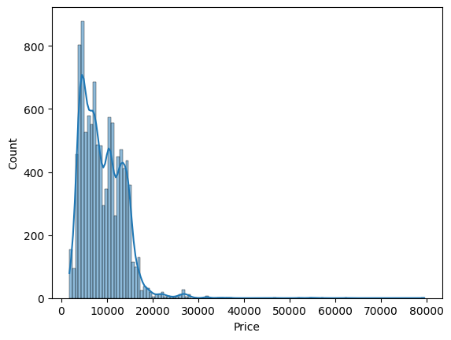

```python
# Price Distribution
sns.histplot(df["Price"], kde=True)
plt.show()
```

This cell displays the density of flight prices, as shown in a histogram and a kernel density estimate. The histogram displays the distribution of ticket prices, and the density curve shows the distribution in a smoother manner. This analysis can be used to detect skewness, outliers and normal price ranges. It is important to know the distribution of the target variable, since it will give you insight into pricing patterns, and will help you decide about any transformations that may be necessary before you train the model.

### Airline vs Price

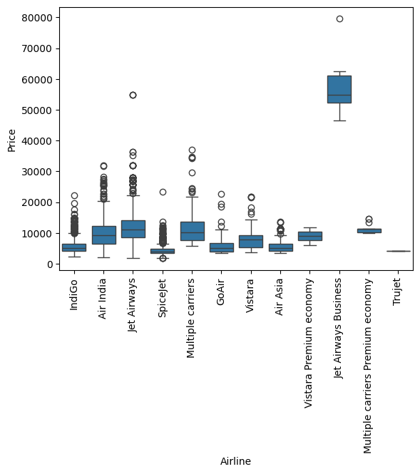

```python
# Airline vs Price
sns.boxplot(
    x="Airline",
    y="Price",
    data=df
)
plt.xticks(rotation=90)
plt.show()
```

This boxplot shows how ticket prices are related to airline companies. The price distribution in each box is for a specific airline. The visualisation allows differences in pricing strategies between airlines to be identified, and also highlights airline variations within each airline. Higher median prices could give airlines an edge on providing high-end services, and lower median prices could demonstrate opportunities for budget travelers. This analysis makes clear that an airline's selection can be a crucial predictor of the cost of a flight.

### Stops vs Price

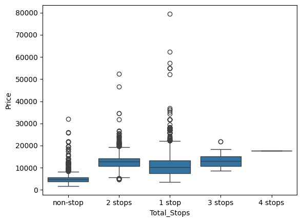

```python
# Stops vs Price
sns.boxplot(
    x="Total_Stops",
    y="Price",
    data=df
)
plt.show()
```

## Step 6 - Feature Engineering

```python
# Date
df["Journey_Day"] = pd.to_datetime(
    df["Date_of_Journey"]
).dt.day

df["Journey_Month"] = pd.to_datetime(
    df["Date_of_Journey"]
).dt.month
```

This cell is used to extract valuable information from the date of the journey variable. The day and the month are constructed as individual features, in particular. When date information is given as numerical attributes instead of text, machine learning models perform better. By separating the day from the month, seasonal variation, monthly demand fluctuation, and travel pattern, which can affect ticket prices, can also be captured by the model.

### Departure Time

```python
# Departure Time
df["Dep_Hour"] = pd.to_datetime(
    df["Dep_Time"]
).dt.hour

df["Dep_Min"] = pd.to_datetime(
    df["Dep_Time"]
).dt.minute
```

This cell will have to extract the hour and the minute from the departure time variable. Ticket prices can be affected by time related information due to the fact that a flight that is scheduled to depart during a “travel rush” could be more expensive than one that is scheduled during a “travel quiet” period. Converting departure times into floating-point numbers allows the neural network to discover relationships between departure times and airline ticket prices.

### Arrival Time

```python
# Arrival Time
df["Arrival_Hour"] = pd.to_datetime(
    df["Arrival_Time"]
).dt.hour

df["Arrival_Min"] = pd.to_datetime(
    df["Arrival_Time"]
).dt.minute
```

This cell gets the hour and minute from the arrival time column. Like departure times, arrival times can affect flight pricing as well, through scheduling decisions and the needs of airline operations. Switching from arrival times to separate numeric variables adds information for the predictive model and helps it to better detect time patterns.

### Duration Feature Engineering

```python
# Duration Feature Engineering

duration = list(df["Duration"])

for i in range(len(duration)):

    # If only hours or only minutes exist
    if len(duration[i].split()) != 2:

        if "h" in duration[i]:
            duration[i] = duration[i] + " 0m"

        else:
            duration[i] = "0h " + duration[i]

duration_hours = []
duration_mins = []

for i in range(len(duration)):

    duration_hours.append(
        int(duration[i].split()[0][:-1])
    )

    duration_mins.append(
        int(duration[i].split()[1][:-1])
    )

df["Duration_Hours"] = duration_hours

df["Duration_Mins"] = duration_mins
```

This cell will process the variable flight duration, which is then broken down into flight hours and flight minutes features. The data for the original duration is numeric, but is stored as text, so there is a need to transform the original data before it can be used by machine learning algorithms. One of the main factors that impact on airfares is the length of the flight; longer flights typically cost more due to the increased resources and operating expenses. Structured duration features bring increased data quality and better predictive capabilities.

```python
df[["Duration","Duration_Hours","Duration_Mins"]].head()
```

|  | Duration | Duration_Hours | Duration_Mins |
| --- | --- | --- | --- |
| 0 | 2h 50m | 2 | 50 |
| 1 | 7h 25m | 7 | 25 |
| 2 | 19h | 19 | 0 |
| 3 | 5h 25m | 5 | 25 |
| 4 | 4h 45m | 4 | 45 |

This cell shows an example of the original duration column, and the new duration hour and duration minute features. To check if feature engineering has been done correctly. Reviewing the small number of transformed records can give an idea of any inconsistencies before moving to model building. One quality assurance step in data processing is to validate engineered features.

## Step - 7 Drop Unnecessary Columns

```python
# Drop Unnecessary Columns
df.drop(
    columns=[
        "Date_of_Journey",
        "Dep_Time",
        "Arrival_Time",
        "Duration",
        "Route"
    ],
    inplace=True
)
```

This cell removes columns in the table which are no longer needed after feature extraction. Routely extracted variables like journey date, departure time, arrival time, duration and route are dropped after being translated to numerical variables where useful information has been captured. Removing duplicated variables makes data sets simpler, and won't cause information to be duplicated when training models.

## Step 8 - Encoding

This cell encodes categories to numbers via one-hot encoding. Narrative information like airline, source, destination, stops, and other information are not directly entered into machine learning models, but instead are converted into a binary indicator variable. The drop_first=True option is used to avoid multicollinearity by dropping one category from each feature group individually encoded. In this step, the data is ready for creation of the deep learning model.

```python
# Encoding
df = pd.get_dummies(
    df,
    columns=[
        'Airline',
        'Source',
        'Destination',
        'Total_Stops',
        'Additional_Info'
    ],
    drop_first=True
)
```

## Step 9 - Define Features and Target

This cell will divide the dataset into independent variables and the target. Flight price is the target variable and all the other columns are the predictors. Separating features and target values is essential since, in supervised learning, we need to have the values of the features and the target values when the algorithms are trained.

```python
# Define Features and Target
X = df.drop("Price", axis=1)

y = df["Price"]
```

## Step 10 - Scaling

This cell normalizes all the predictor variables in the same way as the StandardScaler method. If features are z-scored they are scaled so that their mean is zero and the standard deviation is one. Differences in the magnitude of features in a neural network can cause problems, and if you scale, you get all features to scale the same way during training. This can lead to quicker convergence and higher model accuracy.

```python
# Scaling
scaler = StandardScaler()

X_scaled = scaler.fit_transform(X)
```

## Step 11 - Train-Test Split

This cell splits the data into training data and testing data. 80% of the observations are used for training, 20 % are used for evaluation. The data used for testing is not used in training the model, and thus gives an independent evaluation of the model's performance. This separation is crucial to assess the model's generalization ability to new data.

```python
# Train-Test Split
X_train, X_test, y_train, y_test = train_test_split(
    X_scaled,
    y,
    test_size=0.20,
    random_state=42
)

print(X_train.shape)
print(X_test.shape)
```

```
(8369, 41)
(2093, 41)
```

## Step - 11 Baseline Neural Network

This cell is responsible for creating the basic Artificial Neural Network. The network has several hidden layers and fits one output neuron for regression prediction, where all hidden layer units use the ReLU function. Hiddens layers allow the model to capture the high complexity non-linear relationship between flight characteristics and ticket prices. The architecture will form a foundation for future experiments and performance comparisons.

```python
# Baseline Neural Network
baseline_model = Sequential()

baseline_model.add(
    Dense(
        128,
        activation="relu",
        input_shape=(41,)
    )
)

baseline_model.add(
    Dense(
        64,
        activation="relu"
    )
)

baseline_model.add(
    Dense(
        32,
        activation="relu"
    )
)

baseline_model.add(Dense(1))
```

### Compiling Baseline Model

This Cell sets the attributes of the neural network before training. The Adam optimizer is chosen due to its efficiency and stability in learning. Since it is a continuous numerical prediction task, the loss function is Mean Squared Error. An extra assessment criterion is added: Mean Absolute Error. During training, the network should be optimizable, which can be achieved by proper compilation.

```python
baseline_model.compile(
    optimizer="adam",
    loss="mse",
    metrics=["mae"]
)
```

### Train

This cell will perform the training of the baseline neural network with the training data set. Early stopping is used to avoid over fitting by stopping training if there is no further decrease in validation loss. The model is trained by looking at the patterns of past flights and tuning the internal weights to reduce the errors in predicting the flights. The training is the central part of the project where learning takes place.

```python
# Train
early_stop = EarlyStopping(
    monitor="val_loss",
    patience=10,
    restore_best_weights=True
)

history = baseline_model.fit(
    X_train,
    y_train,
    validation_split=0.20,
    epochs=100,
    batch_size=32,
    callbacks=[early_stop],
    verbose=1
)
```

```
210/210 ━━━━━━━━━━━━━━━━━━━━ 2s 3ms/step - loss: 84493552.0000 - mae: 7956.6338 - val_loss: 22156070.0000 - val_mae: 3592.0667
210/210 ━━━━━━━━━━━━━━━━━━━━ 0s 2ms/step - loss: 10927916.0000 - mae: 2276.0232 - val_loss: 7690932.5000 - val_mae: 1817.5336
210/210 ━━━━━━━━━━━━━━━━━━━━ 0s 2ms/step - loss: 7076991.0000 - mae: 1791.4965 - val_loss: 7090417.0000 - val_mae: 1727.9972
210/210 ━━━━━━━━━━━━━━━━━━━━ 0s 2ms/step - loss: 6290022.5000 - mae: 1698.2169 - val_loss: 6701329.0000 - val_mae: 1633.8009
210/210 ━━━━━━━━━━━━━━━━━━━━ 0s 2ms/step - loss: 5851812.5000 - mae: 1634.6976 - val_loss: 6455067.0000 - val_mae: 1597.6194
210/210 ━━━━━━━━━━━━━━━━━━━━ 0s 2ms/step - loss: 5559746.5000 - mae: 1581.8508 - val_loss: 6270399.0000 - val_mae: 1539.8116
210/210 ━━━━━━━━━━━━━━━━━━━━ 0s 2ms/step - loss: 5326790.0000 - mae: 1539.4326 - val_loss: 6098967.0000 - val_mae: 1504.8054
210/210 ━━━━━━━━━━━━━━━━━━━━ 0s 2ms/step - loss: 5149600.0000 - mae: 1504.6989 - val_loss: 5977953.0000 - val_mae: 1488.7814
210/210 ━━━━━━━━━━━━━━━━━━━━ 0s 2ms/step - loss: 4987771.0000 - mae: 1480.7983 - val_loss: 5852418.0000 - val_mae: 1465.4861
210/210 ━━━━━━━━━━━━━━━━━━━━ 0s 2ms/step - loss: 4860448.0000 - mae: 1448.6835 - val_loss: 5732470.0000 - val_mae: 1469.2012
210/210 ━━━━━━━━━━━━━━━━━━━━ 0s 2ms/step - loss: 4741491.5000 - mae: 1435.9457 - val_loss: 5717796.0000 - val_mae: 1468.9126
210/210 ━━━━━━━━━━━━━━━━━━━━ 0s 2ms/step - loss: 4647576.0000 - mae: 1421.1879 - val_loss: 5666011.0000 - val_mae: 1443.2407
210/210 ━━━━━━━━━━━━━━━━━━━━ 0s 2ms/step - loss: 4573266.5000 - mae: 1407.7096 - val_loss: 5550535.5000 - val_mae: 1420.8639
210/210 ━━━━━━━━━━━━━━━━━━━━ 0s 2ms/step - loss: 4504454.0000 - mae: 1387.4708 - val_loss: 5436412.5000 - val_mae: 1429.1689
210/210 ━━━━━━━━━━━━━━━━━━━━ 0s 2ms/step - loss: 4450452.0000 - mae: 1383.5139 - val_loss: 5377346.5000 - val_mae: 1409.1166
210/210 ━━━━━━━━━━━━━━━━━━━━ 0s 2ms/step - loss: 4384511.0000 - mae: 1369.4177 - val_loss: 5327324.0000 - val_mae: 1401.2726
210/210 ━━━━━━━━━━━━━━━━━━━━ 0s 2ms/step - loss: 4323736.0000 - mae: 1353.2286 - val_loss: 5140011.5000 - val_mae: 1382.5529
210/210 ━━━━━━━━━━━━━━━━━━━━ 1s 3ms/step - loss: 4296792.0000 - mae: 1348.7240 - val_loss: 5087250.5000 - val_mae: 1387.3311
210/210 ━━━━━━━━━━━━━━━━━━━━ 1s 3ms/step - loss: 4228939.0000 - mae: 1334.9165 - val_loss: 5009647.0000 - val_mae: 1373.5292
210/210 ━━━━━━━━━━━━━━━━━━━━ 1s 3ms/step - loss: 4190089.5000 - mae: 1327.0770 - val_loss: 4967844.0000 - val_mae: 1357.4380
210/210 ━━━━━━━━━━━━━━━━━━━━ 1s 2ms/step - loss: 4160574.5000 - mae: 1323.3561 - val_loss: 4910317.0000 - val_mae: 1352.9105
210/210 ━━━━━━━━━━━━━━━━━━━━ 0s 2ms/step - loss: 4101482.2500 - mae: 1310.8904 - val_loss: 4944222.5000 - val_mae: 1347.7823
210/210 ━━━━━━━━━━━━━━━━━━━━ 0s 2ms/step - loss: 4090599.2500 - mae: 1303.7836 - val_loss: 5058694.5000 - val_mae: 1380.2521
210/210 ━━━━━━━━━━━━━━━━━━━━ 0s 2ms/step - loss: 4036313.0000 - mae: 1293.8162 - val_loss: 5095509.5000 - val_mae: 1355.3049
210/210 ━━━━━━━━━━━━━━━━━━━━ 0s 2ms/step - loss: 4019811.2500 - mae: 1287.5092 - val_loss: 5206635.5000 - val_mae: 1370.1776
210/210 ━━━━━━━━━━━━━━━━━━━━ 0s 2ms/step - loss: 3982040.0000 - mae: 1278.7928 - val_loss: 5418885.0000 - val_mae: 1379.6459
210/210 ━━━━━━━━━━━━━━━━━━━━ 0s 2ms/step - loss: 3956070.0000 - mae: 1278.2529 - val_loss: 5624186.5000 - val_mae: 1365.8778
210/210 ━━━━━━━━━━━━━━━━━━━━ 0s 2ms/step - loss: 3916919.7500 - mae: 1267.5155 - val_loss: 5919264.5000 - val_mae: 1366.6039
210/210 ━━━━━━━━━━━━━━━━━━━━ 0s 2ms/step - loss: 3898982.5000 - mae: 1261.1899 - val_loss: 6208857.0000 - val_mae: 1354.9290
210/210 ━━━━━━━━━━━━━━━━━━━━ 0s 2ms/step - loss: 3878140.5000 - mae: 1256.9324 - val_loss: 6658261.5000 - val_mae: 1381.4761
210/210 ━━━━━━━━━━━━━━━━━━━━ 0s 2ms/step - loss: 3838612.7500 - mae: 1248.6675 - val_loss: 6978918.0000 - val_mae: 1352.5001
```

### Baseline Evaluation

This cell uses the trained neural network to make predictions on the test data and produce predicted flight prices. The resulting predictions are then transformed into a 1-D format for easier evaluation. These predictions can be compared with the actual prices to give insight in the efficacy of the model in learning the pricing patterns.

```python
# Baseline Evaluation
y_pred = baseline_model.predict(X_test)

y_pred = y_pred.flatten()
```

```
66/66 ━━━━━━━━━━━━━━━━━━━━ 0s 1ms/step
```

### Measures

This cell compares the predictive accuracy of the baseline model against a number of multiple regression ability measures. The Mean Absolute Error is the average error in the predictions, Root Mean Squared Error is the average of the errors for the largest errors and the R-squared is the percent variance accounted for by the model. In combination, the metrics collectively offer a comprehensive evaluation of model accuracy and reliability.

```python
mae = mean_absolute_error(y_test, y_pred)

mse = mean_squared_error(y_test, y_pred)

rmse = np.sqrt(mse)

r2 = r2_score(y_test, y_pred)

print(mae)
print(rmse)
print(r2)
```

```
1360.6058349609375
2203.800921136027
0.7670660018920898
```

## Step 12 - Experimental Analysis

This cell allows to implement re-usable functions for conducting neural network experiments. The function includes the following parameters: network architecture, optimizer, batch size, epochs, and dropout rate. By automating the experimentation process, many configurations can be tested and evaluated in an efficient manner while keeping the evaluation procedures the same.

```python
# Experimental Analysis
# Create Experiment Function
from tensorflow.keras.models import Sequential
from tensorflow.keras.layers import Dense, Dropout
from tensorflow.keras.callbacks import EarlyStopping

experiment_results = []

def run_experiment(
        exp_name,
        hidden_layers,
        optimizer='adam',
        epochs=100,
        batch_size=32,
        dropout_rate=0):

    model = Sequential()

    model.add(
        Dense(
            hidden_layers[0],
            activation='relu',
            input_shape=(X_train.shape[1],)
        )
    )

    if dropout_rate > 0:
        model.add(Dropout(dropout_rate))

    for neurons in hidden_layers[1:]:

        model.add(
            Dense(
                neurons,
                activation='relu'
            )
        )

        if dropout_rate > 0:
            model.add(Dropout(dropout_rate))

    model.add(Dense(1))

    model.compile(
        optimizer=optimizer,
        loss='mse',
        metrics=['mae']
    )

    early_stop = EarlyStopping(
        monitor='val_loss',
        patience=10,
        restore_best_weights=True
    )

    history = model.fit(
        X_train,
        y_train,
        validation_split=0.20,
        epochs=epochs,
        batch_size=batch_size,
        callbacks=[early_stop],
        verbose=0
    )

    pred = model.predict(X_test, verbose=0)

    if np.isnan(pred).any():
        print(f"{exp_name} produced NaN predictions - skipped")
        return

    mae = mean_absolute_error(y_test, pred)

    rmse = np.sqrt(
        mean_squared_error(y_test, pred)
    )

    r2 = r2_score(y_test, pred)

    experiment_results.append([
        exp_name,
        str(hidden_layers),
        optimizer,
        epochs,
        batch_size,
        dropout_rate,
        mae,
        rmse,
        r2
    ])
```

## Step 13 - Run 10 Experiments

This cell performs the following 10 experiments related to neural networks. Different hyper parameters and architectural configurations are used in each experiment. The goal will be to find the configuration which yields the highest predictive accuracy. Experimenting is an important step in machine learning because the effectiveness of the model may greatly rely on the selection of its parameters.

```python
# Run 10 Experiments
run_experiment("Exp1",[128,64,32],"adam",100,32,0)

run_experiment("Exp2",[64,32],"adam",100,32,0)

run_experiment("Exp3",[256,128,64],"adam",100,32,0)

run_experiment("Exp4",[128,64,32],"rmsprop",100,32,0)

run_experiment("Exp5",[128,64,32],"adam",100,128,0)

run_experiment("Exp6",[128,64,32],"adam",100,32,0.2)

run_experiment("Exp7",[128,64,32],"adam",100,64,0)

run_experiment("Exp8",[128,64,32],"adam",150,32,0)

run_experiment("Exp9",[256,128,64,32],"adam",100,32,0)

run_experiment("Exp10",[512,256,128,64],"adam",100,32,0.2)
```

## Experimental Results Table

All experiments results are organized in a structured DataFrame in this cell. These performance metrics and configuration details are stored to compare. When the results are presented in tabulated form, a comparison of strengths and weaknesses of various model architectures can be easily conducted and the most suitable model architecture may be determined.

```python
# Experimental Results Table
experiment_df = pd.DataFrame(
    experiment_results,
    columns=[
        "Experiment",
        "Architecture",
        "Optimizer",
        "Epochs",
        "Batch_Size",
        "Dropout",
        "MAE",
        "RMSE",
        "R2"
    ]
)

experiment_df
```

|  | Experiment | Architecture | Optimizer | Epochs | Batch_Size | Dropout | MAE | RMSE | R2 |
| --- | --- | --- | --- | --- | --- | --- | --- | --- | --- |
| 0 | Exp1 | [128, 64, 32] | adam | 100 | 32 | 0.0 | 1360.739990 | 2218.015216 | 0.764051 |
| 1 | Exp2 | [64, 32] | adam | 100 | 32 | 0.0 | 1342.488281 | 2172.124306 | 0.773714 |
| 2 | Exp3 | [256, 128, 64] | adam | 100 | 32 | 0.0 | 1399.287354 | 2268.444401 | 0.753200 |
| 3 | Exp4 | [128, 64, 32] | rmsprop | 100 | 32 | 0.0 | 1371.557861 | 2227.203291 | 0.762093 |
| 4 | Exp5 | [128, 64, 32] | adam | 100 | 128 | 0.0 | 1363.613525 | 2187.551485 | 0.770488 |
| 5 | Exp6 | [128, 64, 32] | adam | 100 | 32 | 0.2 | 1395.884277 | 2257.986603 | 0.755471 |
| 6 | Exp7 | [128, 64, 32] | adam | 100 | 64 | 0.0 | 1364.587769 | 2194.265709 | 0.769077 |
| 7 | Exp8 | [128, 64, 32] | adam | 150 | 32 | 0.0 | 1373.053589 | 2216.014779 | 0.764477 |
| 8 | Exp9 | [256, 128, 64, 32] | adam | 100 | 32 | 0.0 | 1410.793335 | 2302.575732 | 0.745718 |
| 9 | Exp10 | [512, 256, 128, 64] | adam | 100 | 32 | 0.2 | 1557.359741 | 2445.629776 | 0.713140 |

## Step 14 - Sort Experiments by Performance

This cell displays the experimental results from the model and tests the model using the R-squared algorithm to see which model performs best. Therefore, if the highest performing configuration is selected, future analysis and recommendations are made based on the best predictive model that was developed through the experimentation process.

```python
# Sort Experiments by Performance
best_model_result = experiment_df.sort_values(
    by="R2",
    ascending=False
).head(1)

best_model_result
```

|  | Experiment | Architecture | Optimizer | Epochs | Batch_Size | Dropout | MAE | RMSE | R2 |
| --- | --- | --- | --- | --- | --- | --- | --- | --- | --- |
| 1 | Exp2 | [64, 32] | adam | 100 | 32 | 0.0 | 1342.488281 | 2172.124306 | 0.773714 |

## Actual vs Predicted Scatter Plot

The actual flight prices are compared with the forecasted prices in this visualization. The points are grouped along the diagonal, showing good predictions. The scatter plot gives a graphical interpretation of the performance of the model and gives an indication of the systematic errors in predictions or of outliers.

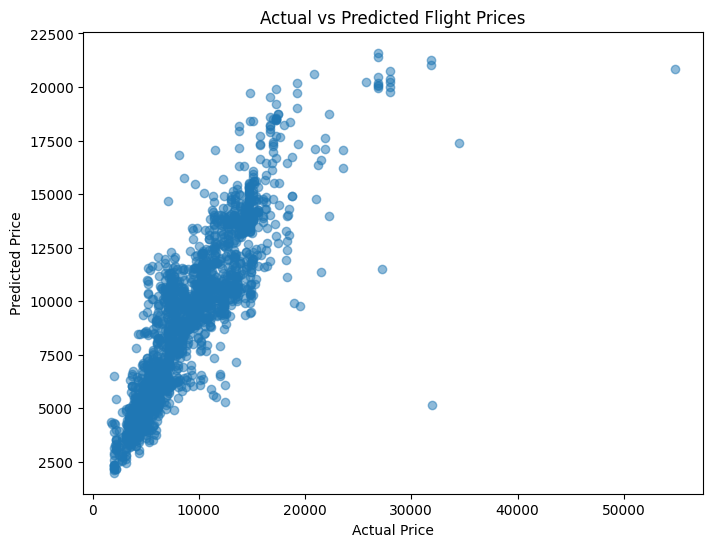

```python
# Actual vs Predicted Scatter Plot
plt.figure(figsize=(8,6))

plt.scatter(
    y_test,
    y_pred,
    alpha=0.5
)

plt.xlabel("Actual Price")
plt.ylabel("Predicted Price")
plt.title("Actual vs Predicted Flight Prices")

plt.show()
```

## Actual vs Predicted Line Plot

This cell provides a line chart of actual and forecasted flight prices. A comparison of the two lines enables an evaluation of the accuracy of the prediction. If the two lines are parallel, there is effective learning, with a high predictive ability.

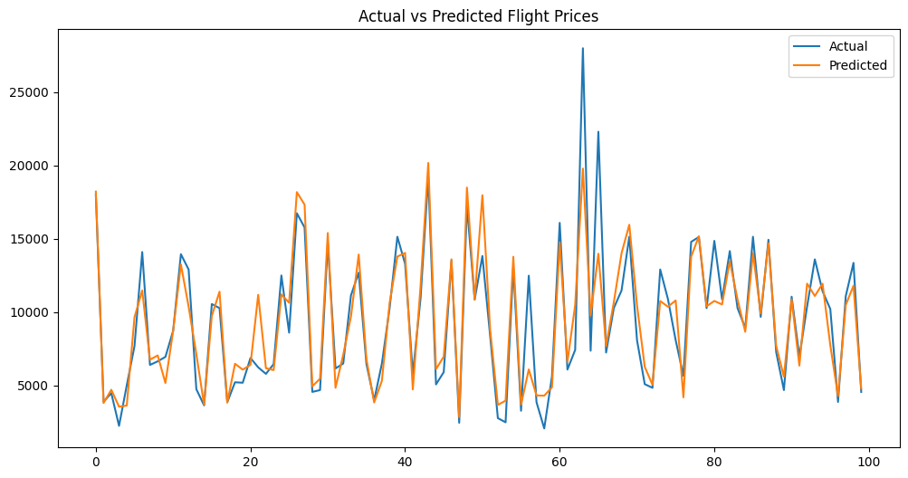

```python
# Actual vs Predicted Line Plot
comparison = pd.DataFrame({
    "Actual": y_test.values,
    "Predicted": y_pred
})

comparison = comparison.head(100)

plt.figure(figsize=(12,6))

plt.plot(comparison["Actual"].values)

plt.plot(comparison["Predicted"].values)

plt.legend(["Actual","Predicted"])

plt.title("Actual vs Predicted Flight Prices")

plt.show()
```

## Residual Distribution

The aim of this cell is to analyze the distribution of residuals, the differences between the actual and predicted prices. Residuals should be centered around zero with a normal distribution. Residual analysis is an aid to detect bias and systematic errors and can suggest ways in which the model can be improved. A relatively even residual distribution suggests that the model's predictions are relatively consistent over the range of prices.

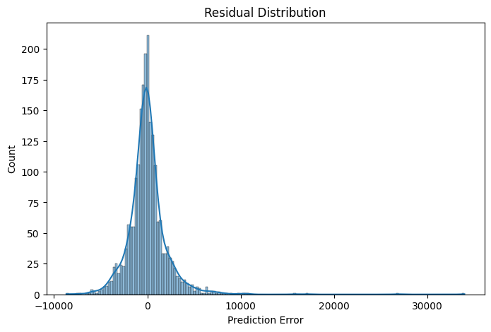

```python
# Residual Distribution
residuals = y_test - y_pred

plt.figure(figsize=(8,5))

sns.histplot(
    residuals,
    kde=True
)

plt.title("Residual Distribution")

plt.xlabel("Prediction Error")

plt.show()
```

The aim of this cell is to analyze the distribution of residuals, the differences between the actual and predicted prices. Residuals should be centered around zero with a normal distribution. Residual analysis is an aid to detect bias and systematic errors and can suggest ways in which the model can be improved. A relatively even residual distribution suggests that the model's predictions are relatively consistent over the range of prices.

**Model Assessment on Unseen Test Set**

The data set was partitioned into an 80:20 training and testing set. The model testing subset was not included in the model training process and is considered unseen data. The performance of the model was assessed by MAE, RMSE and R square values. The performance in terms of RMSE and R² in the unseen test set was satisfactory for the best performing neural network with a value of around 2172.12 and 0.774 respectively.

## Step 15 - Feature Importance Analysis: Train Random Forest

```python
# Feature Importance Analysis
# Train Random Forest
from sklearn.ensemble import RandomForestRegressor

rf = RandomForestRegressor(
    n_estimators=100,
    random_state=42
)

rf.fit(X_train, y_train)
```

```
RandomForestRegressor(random_state=42)
```

### Calculate Importance

A Random Forest model was trained and the feature importance scores are then retrieved and formatted into a structured DataFrame. The importance value is assigned to each feature indicating how much each feature contributes to the model's predictive ability in comparison with others. The features are then sorted in descending order to have the most influential variables towards the top of the table. Showing the highest ranked features gives an idea about which of the flight characteristics is most influential in pricing for tickets. Cost considerations like time on flight, airline choice, number of stops, timing of the departure and arrival and destination often play a major role. Feature importance analysis improves the explainability of the machine learning process, as they give an explanation for how the model is making predictions. The insights gained from these data can be used in business decision making, like pricing strategies, route optimisation, demand forecasting and resource allocation within the airline business.

```python
# Calculate Importance
importance_df = pd.DataFrame({
    "Feature": X.columns,
    "Importance": rf.feature_importances_
})

importance_df = importance_df.sort_values(
    by="Importance",
    ascending=False
)

importance_df.head(10)
```

|  | Feature | Importance |
| --- | --- | --- |
| 6 | Duration_Hours | 0.422507 |
| 0 | Journey_Day | 0.094287 |
| 36 | Additional_Info_In-flight meal not included | 0.077423 |
| 12 | Airline_Jet Airways Business | 0.069312 |
| 11 | Airline_Jet Airways | 0.063492 |
| 1 | Journey_Month | 0.047619 |
| 27 | Destination_New Delhi | 0.029198 |
| 4 | Arrival_Hour | 0.026004 |
| 28 | Total_Stops_2 stops | 0.023076 |
| 2 | Dep_Hour | 0.021542 |

### Feature Importance Plot

Feature importance analysis was performed to find the variables which contribute the most to the flight price prediction. From the results, it can be observed that the feature with the highest influence is Duration_Hours, meaning that longer flights are likely to cost more. Other significant variables are Journey_Day, Additional_Info (In-flight meal not included), Airline type and Journey_Month. The results are in line with the airline price theory, as flight duration, airline service quality, seasonality, and travel schedules are strong determinants of the airline price. The analysis enhances the interpretability of the predictive model, and can give valuable business insights into factors that influence airline ticket pricing.

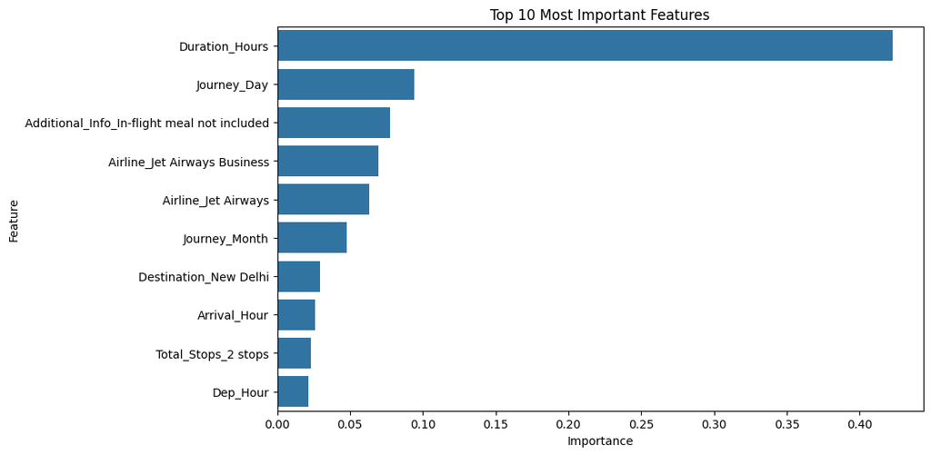

```python
# Plot Importance
plt.figure(figsize=(10,6))

sns.barplot(
    data=importance_df.head(10),
    x="Importance",
    y="Feature"
)

plt.title("Top 10 Most Important Features")

plt.show()
```

### Data Balancing Considerations

For the purpose of this project, there is no need to use any data balancing techniques because it is a regression problem and not a classification problem. Target variable is continuous flight prices, so it is not applicable to class imbalance.

# Business Discussion and Recommendations

## 1. Strengths of the Proposed Solution

The proposed neural network model is an appropriate model to fit the complex and non-linear relationship between flight characteristics and ticket prices. The model performed well in predicting the price of the product, with an R² value of around 0.774, which indicates that the model captures a large portion of the variation in prices. The performance of the models was enhanced as a result of feature engineering. Moreover, several different experimental configurations were tested to optimize the selection of the most appropriate configuration.

## 2. Limitations of the Proposed Solution

Contrary to popular belief, the model is strictly of a historical nature and does not and cannot take into consideration unexpected events in the market like weather delays, fluctuations in fuel prices, economic changes, global crisis, etc. However, with high priced flight tickets, outliers are making prediction more difficult to make with accuracy. In addition, neural networks are typically less interpretable than traditional machine learning models, and must be periodically retrained to ensure that their performance does not degrade.

## 3. Business Recommendations

The results of this study suggest that airlines and travel platforms could consider implementing predictive analytics in their dynamic pricing strategies. Flight duration, airplane type, travel dates and service characteristics should be carefully monitored as they have a big impact on flight fares. Seasonal traffic intensity can be used to create the optimal promotion and pricing strategy. Lastly, predictive models can be embedded in booking systems to enhance customer experience by providing more accurate fare predictions.

## 4. Deployment Considerations & Deployment Decision

The developed model can be deployed using frameworks such as Flask or Streamlit to provide real-time flight price predictions. The model can be used via APIs to be integrated within airline reservation systems. The training of the periodic regime is recommended, based on fresh flight data, to sustain the accuracy of the predictions. Reliable operation at varying market conditions should be obtained by carrying out continuous monitoring.

The proposed model is recommended to be deployed based on the predictive performance and the ability to generate business value from the model. The model can be applied to dynamic pricing, to enhance revenue management and to give an accurate flight fare estimate to the customers. So this model has the potential to be used in real-life airline and travel booking systems.

# Conclusion

This project was successfully able to create the end-to-end flight price prediction system using the deep learning techniques. The data presented in this paper has been thoroughly analyzed, with data cleaning, explorative data analysis, feature engineering, encoding, scaling, and modelling of neural networks. To compare the various neural network configurations, ten different configurations were evaluated to determine the most appropriate configuration. The model with the highest performance gave a coefficient of determination of around 0.774 and proved to be very good at predicting the new samples. The flight duration and travel dates, the airline characteristics, and service-related factors have significant effects on ticket prices, as computed by feature importance analysis. Results show the feasibility of machine learning and deep learning methods for assisting airlines in revenue optimization and customer decision making. By regularly retraining the system and incorporating it into booking platforms, the proposed system can offer precise and reliable forecasts of flight fares in real-world situations.

# Reference List

AlShammari, A.F. (2025). Implementation of Exploratory Data Analysis (EDA) in Python. International Journal of Computer Applications, 187(32), pp.34–42. doi:https://doi.org/10.5120/ijca2025925577.

Dasari, D. and Varma, P.Suresh. (2022). Employing Various Data Cleaning Techniques to Achieve Better Data Quality using Python. doi:https://doi.org/10.1109/iceca55336.2022.10009079.Galli,

S. (2021). Feature-engine: A Python package for feature engineering for machine learning. Journal of Open Source Software, 6(65), p.3642. doi:https://doi.org/10.21105/joss.03642.Gulati,

A., Felahatpisheh, A. and Valderrama, C.E. (2025). Feature engineering through two-level genetic algorithm. Machine Learning with Applications, [online] 21, p.100696. doi:https://doi.org/10.1016/j.mlwa.2025.100696.Kim,

J., Lee, M., Lee, M.K., Wang, S.-M., Kim, N.-Y., Kang, D.W., Um, Y.H., Na, H.-R., Woo, Y.S., Lee, C.U., Bahk, W.-M., Kim, D. and Lim, H.K. (2021). Development of Random Forest Algorithm Based Prediction Model of Alzheimer’s Disease Using Neurodegeneration Pattern. Psychiatry Investigation, 18(1), pp.69–79. doi:https://doi.org/10.30773/pi.2020.0304.Korkmaz,

H. (2024). Prediction of Airline Ticket Price Using Machine Learning Method. Journal of Transportation and Logistics, 0(0). doi:https://doi.org/10.26650/jtl.2024.1486696.Oladipupo,

M.A., Obuzor, P.C., Bamgbade, B.J., Adeniyi, A.E., Olagunju, K.M. and Ajagbe, S.A. (2023). An Automated Python Script for Data Cleaning and Labeling using Machine Learning Technique. Informatica, 47(6). doi:https://doi.org/10.31449/inf.v47i6.4474.Sun,

X., Zheng, C., Wandelt, S. and Zhang, A. (2024). Airline competition: A comprehensive review of recent research. Journal of the Air Transport Research Society, 2(100013), pp.1–17. doi:https://doi.org/10.1016/j.jatrs.2024.100013.Sundaram,

J., Gowri, K., Devaraju, S., Gokuldev, S., Jayaprakash, S., Anandaram, H., Manivasagan, C. and Thenmozhi, M. (2023). An Exploration of Python Libraries in Machine Learning Models for Data Science. Advances in computational intelligence and robotics book series, [online] pp.1–31. doi:https://doi.org/10.4018/978-1-6684-8696-2.ch001.

# Appendix

Dataset link - https://www.kaggle.com/datasets/jillanisofttech/flight-price-prediction-dataset

Github link - https://github.com/harjot37/flight-price-prediction-neural-network